# CSCI E-89 Deep Learning, Assignment 03, Problem 5

**Name:** Andra Constandache  
**Tool:** OpenAI Codex  
**Generated from a single prompt in a new Codex session.**

## Load and inspect FashionMNIST

Load the template dataset with torchvision transforms v2 and create the seeded 55,000/5,000 training and validation split. Build batch-size-32 loaders with only the training loader shuffled, then inspect a sample and a batch.

```python
# Imports and reproducible FashionMNIST input pipeline.
import json
import torch
import torch.nn as nn
import torchvision
import torchvision.transforms.v2 as T
from torch.utils.data import DataLoader
import torchmetrics
import matplotlib.pyplot as plt
import numpy as np
import torch.nn.functional as F

# Prefer CUDA, then MPS, and fall back to CPU.
if torch.cuda.is_available():
    device = "cuda"
elif torch.backends.mps.is_available():
    device = "mps"
else:
    device = "cpu"
print("Device:", device)
if device == "cuda":
    print("GPU:", torch.cuda.get_device_name(0))

# Apply the template image conversion and load both FashionMNIST splits.
toTensor = T.Compose([T.ToImage(), T.ToDtype(torch.float32, scale=True)])
train_and_valid_data = torchvision.datasets.FashionMNIST(
    root="datasets", train=True, download=True, transform=toTensor)
test_data = torchvision.datasets.FashionMNIST(
    root="datasets", train=False, download=True, transform=toTensor)

# Reproduce Geron's seeded 55,000/5,000 split and batch-size-32 loaders.
torch.manual_seed(42)
train_data, valid_data = torch.utils.data.random_split(
    train_and_valid_data, [55_000, 5_000])
torch.manual_seed(42)
train_loader = DataLoader(train_data, batch_size=32, shuffle=True)
valid_loader = DataLoader(valid_data, batch_size=32)
test_loader = DataLoader(test_data, batch_size=32)

# Inspect one image and one mini-batch as in the template.
X_sample, y_sample = train_data[0]
X_batch, y_batch = next(iter(train_loader))
print(f"Train: {len(train_data)}, Valid: {len(valid_data)}, Test: {len(test_data)}")
print(f"Sample: {tuple(X_sample.shape)}, {X_sample.dtype}, {train_and_valid_data.classes[y_sample]}")
print(f"Batch: {tuple(X_batch.shape)}, labels: {tuple(y_batch.shape)}")
```

```
Device: cuda
GPU: NVIDIA GeForce RTX 3050 Ti Laptop GPU
Train: 55000, Valid: 5000, Test: 10000
Sample: (1, 28, 28), torch.float32, Ankle boot
Batch: (32, 1, 28, 28), labels: (32,)
```

## Define the image classifier

Define Geron’s 784-300-100-10 multilayer perceptron with ReLU activations. Initialize it with the template seed, move it to the selected device, and inspect its parameter count and initial cross-entropy loss.

```python
# Define the template MLP classifier.
class ImageClassifier(nn.Module):
    def __init__(self, n_inputs, n_hidden1, n_hidden2, n_classes):
        super().__init__()
        self.mlp = nn.Sequential(
            nn.Flatten(),
            nn.Linear(n_inputs, n_hidden1),
            nn.ReLU(),
            nn.Linear(n_hidden1, n_hidden2),
            nn.ReLU(),
            nn.Linear(n_hidden2, n_classes)
        )

    def forward(self, X):
        return self.mlp(X)

# Initialize deterministically, and inspect the initial model and loss.
torch.manual_seed(42)
model = ImageClassifier(n_inputs=1 * 28 * 28, n_hidden1=300,
                        n_hidden2=100, n_classes=10).to(device)
xentropy = nn.CrossEntropyLoss()
print(model)
print(f"Trainable parameters: {sum(p.numel() for p in model.parameters()):,}")
X0, y0 = X_batch.to(device), y_batch.to(device)
with torch.no_grad():
    initial_logits = model(X0)
print("Logits shape:", tuple(initial_logits.shape))
print(f"Initial cross-entropy loss: {xentropy(initial_logits, y0).item():.4f}")
```

```
ImageClassifier(
  (mlp): Sequential(
    (0): Flatten(start_dim=1, end_dim=-1)
    (1): Linear(in_features=784, out_features=300, bias=True)
    (2): ReLU()
    (3): Linear(in_features=300, out_features=100, bias=True)
    (4): ReLU()
    (5): Linear(in_features=100, out_features=10, bias=True)
  )
)
Trainable parameters: 266,610
Logits shape: (32, 10)
Initial cross-entropy loss: 2.3086
```

## Train and evaluate for 20 epochs

Use Geron’s evaluation and training pattern, SGD with learning rate 0.1, and multiclass accuracy. Print train loss and train/validation accuracy for every epoch, then save the learned weights and history.

```python
# Evaluate a model on a complete loader without computing gradients.
def evaluate_tm(model, data_loader, metric):
    model.eval()
    metric.reset()
    with torch.no_grad():
        for X_batch, y_batch in data_loader:
            X_batch, y_batch = X_batch.to(device), y_batch.to(device)
            y_pred = model(X_batch)
            metric.update(y_pred, y_batch)
    return metric.compute()

# Train with mini-batches, recording mean loss and both accuracy metrics.
def train2(model, optimizer, criterion, metric, train_loader, valid_loader, n_epochs):
    history = {"train_losses": [], "train_metrics": [], "valid_metrics": []}
    for epoch in range(n_epochs):
        total_loss = 0.
        metric.reset()
        for X_batch, y_batch in train_loader:
            model.train()
            X_batch, y_batch = X_batch.to(device), y_batch.to(device)
            y_pred = model(X_batch)
            loss = criterion(y_pred, y_batch)
            total_loss += loss.item()
            loss.backward()
            optimizer.step()
            optimizer.zero_grad()
            metric.update(y_pred, y_batch)
        history["train_losses"].append(total_loss / len(train_loader))
        history["train_metrics"].append(metric.compute().item())
        history["valid_metrics"].append(
            evaluate_tm(model, valid_loader, metric).item())
        print(f"Epoch {epoch + 1}/{n_epochs}, train loss: {history['train_losses'][-1]:.4f}, "
              f"train accuracy: {history['train_metrics'][-1]:.4f}, "
              f"validation accuracy: {history['valid_metrics'][-1]:.4f}")
    return history

# Reinitialize with the template seed and train using Geron's optimizer settings.
n_epochs = 20
torch.manual_seed(42)
model = ImageClassifier(n_inputs=1 * 28 * 28, n_hidden1=300,
                        n_hidden2=100, n_classes=10).to(device)
xentropy = nn.CrossEntropyLoss()
optimizer = torch.optim.SGD(model.parameters(), lr=0.1)
accuracy = torchmetrics.Accuracy(task="multiclass", num_classes=10).to(device)
history = train2(model, optimizer, xentropy, accuracy, train_loader, valid_loader, n_epochs)
torch.save(model.state_dict(), "model_weights.pt")
with open("train_history.json", "w", encoding="utf-8") as f:
    json.dump(history, f, indent=2)
print("Saved model_weights.pt and train_history.json")
```

[output not shown]

```
Saved model_weights.pt and train_history.json
```

## Plot training accuracy

Visualize training accuracy across all 20 epochs. The figure includes axis labels, title, grid, legend, and an annotation for the final value.

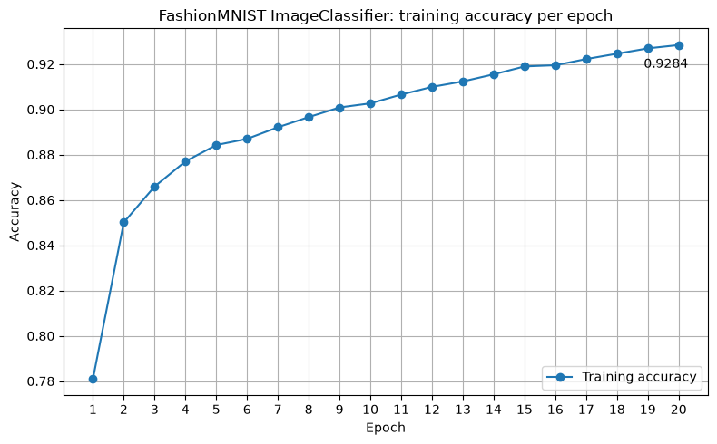

```python
# Plot the saved training accuracy history across all epochs.
train_accuracy = np.asarray(history["train_metrics"])
epochs = np.arange(1, len(train_accuracy) + 1)
plt.figure(figsize=(8, 5))
plt.plot(epochs, train_accuracy, "o-", label="Training accuracy")
plt.annotate(f"{train_accuracy[-1]:.4f}", xy=(epochs[-1], train_accuracy[-1]),
             xytext=(-10, -18), textcoords="offset points", ha="center")
plt.xlabel("Epoch")
plt.ylabel("Accuracy")
plt.title("FashionMNIST ImageClassifier: training accuracy per epoch")
plt.xticks(epochs)
plt.grid(True)
plt.legend(loc="lower right")
plt.tight_layout()
plt.savefig("accuracy_plot.png", dpi=150)
plt.show()
```

## Predict three validation images

Run inference without gradients on the first three validation images. Print predicted class, true class, and softmax confidence, and show the images with both labels.

```
Predicted class names: ['Sneaker', 'Coat', 'Pullover']
True class names:      ['Sneaker', 'Coat', 'Pullover']
Image 1: predicted Sneaker (85.9% confidence), true Sneaker -> correct
Image 2: predicted Coat (99.6% confidence), true Coat -> correct
Image 3: predicted Pullover (80.9% confidence), true Pullover -> correct
```

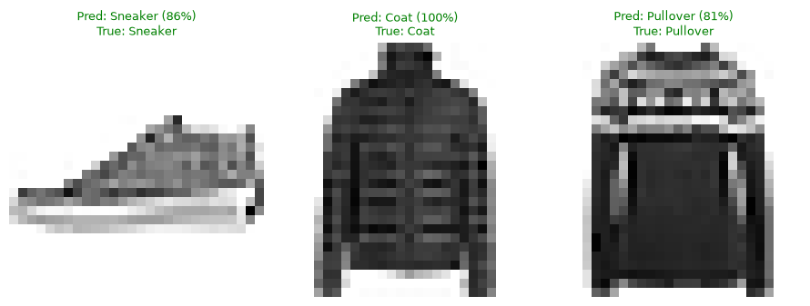

```python
# Predict the first three examples of the first validation batch.
model.eval()
X_new, y_new = next(iter(valid_loader))
X_new, y_new = X_new[:3].to(device), y_new[:3]
with torch.no_grad():
    y_pred_logits = model(X_new)
y_pred = y_pred_logits.argmax(dim=1)
y_proba = F.softmax(y_pred_logits, dim=1).cpu()
class_names = train_and_valid_data.classes
print("Predicted class names:", [class_names[i] for i in y_pred.tolist()])
print("True class names:     ", [class_names[i] for i in y_new.tolist()])
for i, (pred, true) in enumerate(zip(y_pred.tolist(), y_new.tolist())):
    verdict = "correct" if pred == true else "WRONG"
    print(f"Image {i + 1}: predicted {class_names[pred]} "
          f"({y_proba[i, pred]:.1%} confidence), true {class_names[true]} -> {verdict}")
fig, axes = plt.subplots(1, 3, figsize=(9, 3.5))
for i, ax in enumerate(axes):
    pred, true = y_pred[i].item(), y_new[i].item()
    ax.imshow(X_new[i].cpu().squeeze(), cmap="binary")
    ax.set_title(f"Pred: {class_names[pred]} ({y_proba[i, pred]:.0%})\nTrue: {class_names[true]}",
                 color="green" if pred == true else "red", fontsize=9)
    ax.axis("off")
plt.tight_layout()
plt.show()
```

## Conclusion

Final training accuracy: **92.84%**. Final validation accuracy: **87.34%**. The 5.50 percentage-point gap indicates some overfitting: the model fits the training examples better than held-out examples. Validation accuracy also fluctuated and peaked at 88.70% in epoch 18, so the final epoch was not the best validation checkpoint. The assigned run uses the final epoch weights, as in the Geron template.